# IGF1R-3QQU - Calx-β Molecular Dynamics with Gromacs

Load and interactively visualize files in `../data/3d_struct/` with **nglview**, then (optional) run a **GROMACS** binding-site MD simulation of **calx-β** on **IGF1R (3QQU)**.

**Input Files:**

| File | Contents |
| --- | --- |
| 3QQU.pdbqs | IGF1R kinase receptor (AutoDock grid map source) |
| calxbeta_18.39.pdb | Calx-β docked to IGF1R (−18.39 kcal/mol) |

**Not used here yet:**

| File | Contents |
| --- | --- |
| `IVM_3qqu_mid_17.25.pdb` | Ivermectin docked pose, run 13 (−17.25 kcal/mol) |
| `IVM_17.45_3QQU.pdb` | Ivermectin docked pose, run 11 (−17.45 kcal/mol) |

**Run in the MD container** (`./up-md.sh --build` from `tomo_2026b/md/`).

```
Structure folder: /workspace/tomo_2026b/md/data/3d_struct
Found 4 file(s)
MD_ROOT=/workspace/tomo_2026b/md/data/md_calx_3qqu  production=100000 ps  RUN_MD=False  USE_GPU_MDRUN=True
```

| name | value | what_it_does |
| --- | --- | --- |
| STRUCT_DIR | /workspace/tomo_2026b/md/data/3d_struct | Folder with input receptor / ligand structures |
| STRUCT_FILES | 4 files | List of structure files found under STRUCT_DIR |
| RECEPTOR_PATH | /workspace/tomo_2026b/md/data/3d_struct/3QQU.pdbqs | IGF1R kinase structure (3QQU) |
| LIGAND_PATH | /workspace/tomo_2026b/md/data/3d_struct/calxbeta_18.39.pdb | Docked calx-β pose used to build the complex |
| MD_ROOT | /workspace/tomo_2026b/md/data/md_calx_3qqu | Workspace MD directory (topology, equilibration, synced outputs) |
| RUNS_DIR | /workspace/tomo_2026b/md/data/runs | Archive directory for copied run logs |
| MD_TMP_ROOT | /tmp/md_calx_3qqu | Local /tmp path for production mdrun (avoids gcsfuse) |
| TRJCONV_OUTPUT_GROUP | Protein | Atom group in md_pbc.xtc (Protein = receptor + calx-β, no water) |
| TRJCONV_DT_PS | 100 | Stride for analysis trajectory (ps); smaller file and less RAM |
| CALX_BETA_CARTOON_COLOR | #377eb8 | nglview / PNG color for calx-β |
| RECEPTOR_POCKET_CARTOON_COLOR | #e41a1c | nglview / PNG color for receptor pocket |
| RUN_MD | False | If True, run GROMACS; if False, only build pocket / inputs |
| FORCE_FROM_SCRATCH | True | If True, ignore md.cpt and re-run solvation + equilibration |
| FORCE_MD_REPROCESS | True | If True, rebuild final PDB / energy plots from the trajectory |
| FORCE_BINDING_REPROCESS | True | If True, recompute ligand RMSD and contact metrics |
| TOTAL_STEPS | 50000000 | Production MD step count (simulation length = TOTAL_STEPS × MD_DT_PS) |
| MD_DT_PS | 0.002 | Integration timestep in picoseconds (0.002 ps = 2 fs) |
| production_ps | 100000 | Derived production length in picoseconds |
| TRAJ_SAVE_PS | 10 | Interval for writing trajectory / energy frames (ps) |
| CHECKPOINT_SAVE_PS | 1000 | Checkpoint write interval in picoseconds (1000 ps = 1 ns) |
| CHECKPOINT_SAVE_STEPS | 500000 | Checkpoint interval in steps (from CHECKPOINT_SAVE_PS / MD_DT_PS) |
| USE_GPU_MDRUN | True | If True, offload production mdrun nonbonded/PME/bonded/update to GPU |
| MDRUN_GPU_FLAGS | -nb gpu -pme gpu -bonded gpu -update gpu | gmx mdrun GPU offload flags used when USE_GPU_MDRUN is True |
| EM_STEPS | 5000 | Energy-minimization step count |
| NVT_STEPS | 25000 | NVT equilibration step count |
| NPT_STEPS | 25000 | NPT equilibration step count |
| POCKET_CUTOFF_NM | 1 | Receptor atoms kept near ligand when building the pocket (nm) |
| FORCEFIELD | amber99sb-ildn | GROMACS protein force field for pdb2gmx |
| WATER_MODEL | tip3p | Water model paired with the force field |

|  | file | suffix | n_atoms | n_residues | n_models | docked_energy_kcal_mol | warnings |
| --- | --- | --- | --- | --- | --- | --- | --- |
| 0 | 3QQU.pdbqs | .pdbqs | 2702 | 285 | 1 | NaN | Truncating .pdbqs ATOM records to 80-column PD... |
| 1 | IVM_17.45_3QQU.pdb | .pdb | 65 | 1 | 1 | -17.45 | RTF wrapper detected — extracting ATOM/MODEL r... |
| 2 | IVM_3qqu_mid_17.25.pdb | .pdb | 65 | 1 | 1 | -17.25 |  |
| 3 | calxbeta_18.39.pdb | .pdb | 1190 | 119 | 1 | NaN |  |

## Structures

Each panel is one file from `data/3d_struct/`. Large receptors use **cartoon**; docked ligands use **ball+stick**.

**3QQU.pdbqs**

```
note: Truncating .pdbqs ATOM records to 80-column PDB for nglview
atoms=2702  residues=285  models=1
```

```
NGLWidget()
```

**calxbeta_18.39.pdb**

```
atoms=1190  residues=119  models=1
```

```
NGLWidget()
```

**This notebook is set for a 100 ns production run** (`TOTAL_STEPS = 50_000_000` at 2 fs). Production `mdrun` uses GPU offload (`-nb gpu -pme gpu -bonded gpu -update gpu`) when `USE_GPU_MDRUN = True` — run the kernel in the CUDA image (`./md-run.sh --gpu`). Equilibration (EM/NVT/NPT) runs on CPU `mdrun` under `data/md_calx_3qqu/` (gcsfuse). **Production** `grompp` + `mdrun` run under **`/tmp/md_calx_3qqu/`** (local disk); outputs are copied back to `data/md_calx_3qqu/` when the run finishes (and after each checkpoint write).

### Why `/tmp` for production

The workspace path is backed by **gcsfuse**. Long production runs write large, frequent files (`md.xtc`, `md.cpt`, `md.edr`, `md.log`). On gcsfuse these writes are slow and can block the Jupyter kernel (sometimes seen as `KeyboardInterrupt` during VM teardown). Local `/tmp` avoids that I/O path for the hours-long production step.

### Why `/tmp` for post-processing

After production, `gmx trjconv` rebuilds `md_pbc.xtc` from the full `md.xtc` (~48k atoms with water). Writing that file on gcsfuse and then loading it with `md.load` can use several GB of RAM and **kill the kernel**. Post-processing runs `trjconv` on **local `/tmp`**, keeps **Protein only** (receptor + calx-β), optionally **strides** frames (`TRJCONV_DT_PS`), and copies the finished `md_pbc.xtc` back to `data/md_calx_3qqu/` once.

### Checkpoints every 1 ns (`nstcheckpoint = 500000`)

At `dt = 0.002` ps (2 fs), 1 ns = 1000 ps → **500000 steps** between checkpoint writes. GROMACS keeps a single `md.cpt` file and overwrites it each time; the default interval (~15 min wall time, ~40k steps) caused too many gcsfuse writes when production ran on the workspace. With production on `/tmp`, checkpoints still use a 1 ns interval so a VM loss loses at most ~1 ns of simulation time.

**Re-grompp for a new checkpoint interval:** `nstcheckpoint` is stored in `md.tpr` at `grompp` time. Editing `md.mdp` alone does not change an existing `md.tpr`. To use the 1 ns interval, re-run production `grompp` (pipeline step 7) before the next `mdrun`. You can still resume from an existing `md.cpt` with `-cpi md.cpt`; only the *future* checkpoint schedule comes from the new `.tpr`.

### Must re-run helper cells after any notebook sync

Jupyter keeps **old function bodies in the kernel** until you re-execute them. After pulling/syncing this file into `/workspace`, **re-run the MD setup cells** that define `sync_md_to_tmp` / `run_gmx` / `production_mdrun_args` / `run_md_pipeline`, and the analysis helpers (`ensure_pbc_corrected_trajectory` / `load_md_trajectory`) (the cells under this section) **before** the `RUN_MD` pipeline cell. Confirm the helper printout mentions `/tmp/md_calx_3qqu`.

Verbose GROMACS stdout is written under **`/tmp`** during long runs, with progress milestones only in the notebook; the log is copied into `data/runs/` when the pipeline finishes.

**Session idle / teardown:** If the launch UI shows "Idle timeout very soon" / remaining `0:00`, the VM may tear down soon and the kernel will raise `KeyboardInterrupt` even while `mdrun` is progressing. Extend idle time from the session control bar and confirm remaining time is non-zero before starting a multi-hour production run.

### Re-entrant `RUN_MD` (automatic resume)

When **`data/md_calx_3qqu/md.cpt`** exists in the workspace (GCS via gcsfuse), re-run the helper cells and the **`RUN_MD` cell** — it **does not** repeat solvation, EM, NVT, or NPT. It:

1. Copies the latest checkpoint and matching inputs from workspace → **`/tmp/md_calx_3qqu/`**
2. If `md.tpr` still has a shorter `nsteps` than `TOTAL_STEPS` (for example a leftover 1 ns tpr with `nsteps = 500000`), runs **`gmx convert-tpr -nsteps`** so production can continue to 100 ns **without** restarting from NPT
3. Runs production `mdrun` with **`-cpi md.cpt`** on local disk (GPU flags when enabled)
4. Copies **`md.cpt` back to the workspace after each checkpoint write** (~every 1 ns), then full outputs at the end

Set **`FORCE_FROM_SCRATCH = True`** in the config cell to ignore an existing checkpoint and run the full pipeline from solvation.

**Do not re-run production `grompp` from `npt.gro` on resume** — that would restart production from NPT instead of the checkpoint. Resume keeps **`md.cpt`** and only updates the step limit in **`md.tpr`**. After a 100 ns trajectory exists, re-run the PBC / analysis cells (`FORCE_MD_REPROCESS` / `FORCE_BINDING_REPROCESS` if those flags skip existing outputs).

To change `nstcheckpoint` after a run has started, finish or discard the run and start fresh with `FORCE_FROM_SCRATCH = True`.

[output not shown]

```
NGLWidget()
```

```
MDP files: ions.mdp, em.mdp, nvt.mdp, npt.mdp, md.mdp | EM 5,000  NVT/NPT 25,000  production 50,000,000 steps
RE-RUN OK: production uses /tmp/md_calx_3qqu (local disk). Checkpoints every 500,000 steps (1000 ps). When md.cpt exists in workspace, RUN_MD resumes production only (no equilibration).
```

```
RE-RUN OK: production_mdrun_args() runs under /tmp/md_calx_3qqu with -cpi md.cpt when present. Confirm Idle time remaining > 0 before long mdrun.
```

```
RUN_MD=False — pocket/complex built; set RUN_MD=True to execute GROMACS.
```

```
PBC correction: md.xtc → md_pbc.xtc (Protein-only, dt=100.0 ps, local /tmp)
$ gmx trjconv -s md.tpr -f md.xtc -pbc mol -center -ur compact -o /tmp/md_calx_3qqu/md_pbc.xtc -dt 100.0
Copied md_pbc.xtc (11.0 MB) → /workspace/tomo_2026b/md/data/md_calx_3qqu
Writing Protein-only topology → md_protein.gro (via /tmp)
$ gmx trjconv -s md.tpr -f npt.gro -o /tmp/md_calx_3qqu/md_protein.gro -dump 0
<mdtraj.Trajectory with 1001 frames, 2847 atoms, 176 residues, and unitcells>
$ gmx energy -f md.edr -o md_ener.xvg

Statistics over 50000001 steps [ 0.0000 through 100000.0000 ps ], 1 data sets
All statistics are over 500001 points

Energy                      Average   Err.Est.       RMSD  Tot-Drift
-------------------------------------------------------------------------------
Potential                   -673181        6.4    883.122   -18.2001  (kJ/mol)

Wrote /workspace/tomo_2026b/md/data/md_calx_3qqu/md_ener.xvg
Wrote /workspace/tomo_2026b/md/data/md_calx_3qqu/md_final_protein.pdb
```

```
Saved MD results manifest: /workspace/tomo_2026b/md/data/md_calx_3qqu/md_results_manifest.json
```

```
PosixPath('/workspace/tomo_2026b/md/data/md_calx_3qqu/md_results_manifest.json')
```

```
NGLWidget()
```

**Production MD — final frame** (full IGF1R **gray**, pocket **red**, calx-β **blue**; receptor aligned to MD pocket Cαs)

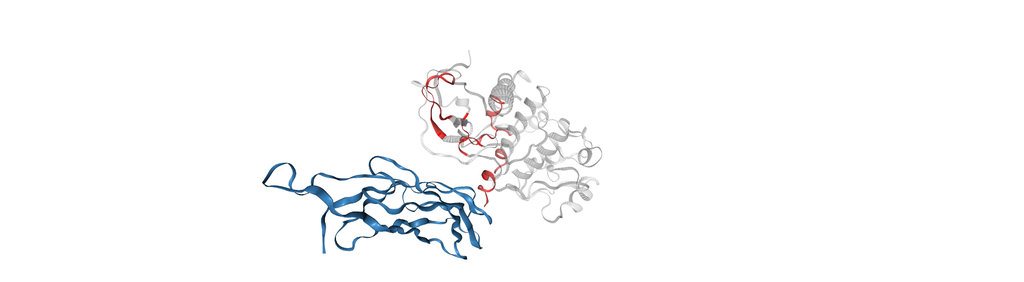

```
Manifest: /workspace/tomo_2026b/md/data/md_calx_3qqu/md_results_manifest.json (saved 2026-08-22T15:38:12.196511+00:00)
```

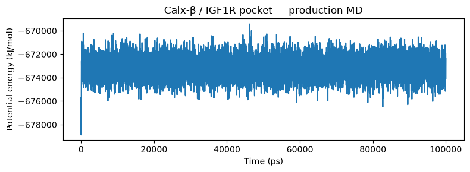

```
True
```

```
Computing binding metrics: 1001 frames, 100000 ps
Saved binding metrics: /workspace/tomo_2026b/md/data/md_calx_3qqu/md_binding_metrics.csv
```

|  | time_ps | ligand_rmsd_nm | receptor_contacts | receptor_contact_residues |
| --- | --- | --- | --- | --- |
| count | 1001.000 | 1001.000 | 1001.000 | 1001.000 |
| mean | 50000.000 | 0.248 | 64.587 | 19.114 |
| std | 28910.811 | 0.036 | 26.686 | 6.531 |
| min | 0.000 | 0.000 | 6.000 | 3.000 |
| 25% | 25000.000 | 0.218 | 42.000 | 15.000 |
| 50% | 50000.000 | 0.245 | 67.000 | 19.000 |
| 75% | 75000.000 | 0.281 | 83.000 | 24.000 |
| max | 100000.000 | 0.330 | 130.000 | 35.000 |

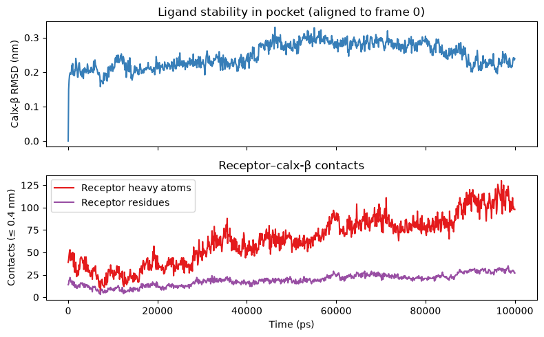

Binding stability assessment (heuristic)

- **Trajectory length:** 100000 ps (1001 frames)

- **Static dock score (Vina):** -18.39 kcal/mol (pose quality only, not MD ΔG)

- **Calx-β RMSD vs t=0:** median 0.25 nm, max 0.33 nm, late−early drift +0.04 nm → **moderately mobile but largely retained**

- **Receptor contacts (≤ 0.4 nm):** median 67 heavy-atom pairs / 19 residues, min 3 residues → Receptor contacts are **partially maintained** (some fluctuation).

**Overall:** The complex appears **relatively stable** over this production run: calx-β stays near the docked pose with sustained pocket contacts. This supports **retained binding** over 100.0 ns; MM-PBSA/GBSA is still required for quantitative ΔG_bind.

*Note: RMSD and contact metrics do not equal binding free energy. MM-PBSA/GBSA is still required for quantitative ΔG_bind.*

[output not shown]